# Consequences of Covid-19 for Candle Critiques

## Part 2: Combined plot

Combine the two datasets into one and make a plot similar to above, but showing both unscented and scented candles. Distinguish scented versus unscented candles using color, shape, and line type (for the trend lines).

```r
candles_full <- bind_rows(
    scented_candles = Scented_all,
    unscented_candles = Unscented_all,
    .id = "Scented"
)
```

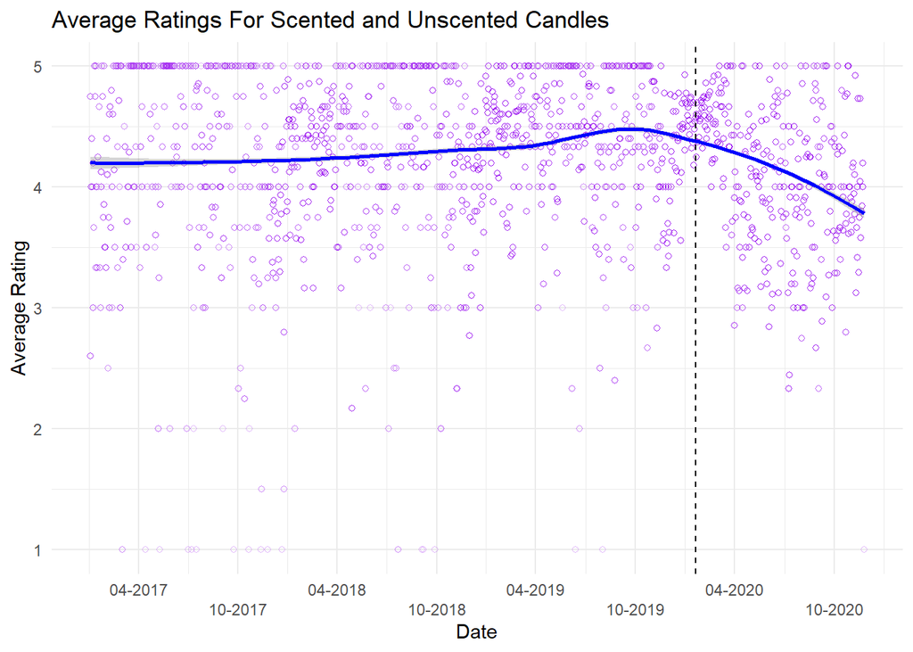

```r
plot_combined <- candles_full %>%
  filter(Date > "2017-01-01") %>%
  group_by(Date) %>%
  mutate(Avg_Rating = mean(Rating)) %>%
  ggplot(
    aes(x = as.Date(Date),
        y = Avg_Rating
  )) +
  geom_point(alpha = .3,
             shape = 1,
             color = "purple") +
  scale_x_date(name = "Date",
               date_breaks = "6 months",
               date_labels = "%m-%Y") +
  geom_smooth(method = "loess",
              color = "blue") +
  geom_vline(xintercept = as.numeric(as.Date("2020-01-20")),
             linetype = "dashed") +
  scale_y_continuous(name = "Average Rating") +
  theme_minimal() +
  ggtitle("Average Ratings For Scented and Unscented Candles") +
  guides(x = guide_axis(n.dodge = 2))

plot_combined
```

Which of these two sets of plots do you find easier to interpret?

## Part 3: Proportion of reviews mentioning “no scent”

Use the scented candles database and make one more plot showing:

1. For **each month in 2019 and 2020**,
2. On the x axis, month and year
3. On the y axis, the **proportion of reviews** mentioning that the scented candles have no smell - Include both the mean (proportion) and a 95% confidence interval
4. Color the symbols by year (2019 vs 2020)

Hints:

[figure not shown]

```r
plot2 <- Scented_all %>%
  filter(Date >= "2019-01-01") %>%
  mutate(month = lubridate::floor_date(Date,
                                       "month")
         ) %>%
  group_by(month,
           CodedReview_f) %>%
  ggplot() +
  aes(x = month,
      y = (..count..)/sum(..count..)) +
  geom_bar(position = "dodge",
           fill = "violet") +
  stat_summary(aes(y = CodedReview_f),
               fun.data = mean_cl_normal)

plot2
```

What pattern do you see? Is there a trend over time regarding smell-related reviews? How does 2020 compare to 2019?